# Credit Card Customer Data Project / Yeoman Yoon

## Problem:

AllLife Bank wants to improve the marketing strategy by personalizing campaigns on new customers and upselling existing customers. At the same time, Delivery team wants to improve customer services by speeding up the customer service process.

## Resolution:

Clustering Machine Learning.

```python
import pandas as pd
import numpy as np
from sklearn import metrics
import matplotlib.pyplot as plt
%matplotlib inline
import seaborn as sns
from sklearn.preprocessing import StandardScaler
from sklearn import metrics
# K-Mean clustering
from scipy.spatial.distance import cdist
from sklearn.cluster import KMeans
from sklearn.metrics import silhouette_score
# Hierarchical clustering
from scipy.spatial.distance import pdist
from sklearn.cluster import AgglomerativeClustering
from scipy.cluster.hierarchy import dendrogram, linkage, cophenet
# PCA
from sklearn.decomposition import PCA
```

## Import Data

```python
bank = pd.read_excel('CreditCardCustomerData.xlsx') # use copy to store the original data
data = bank.copy()
```

```python
data.head(10)
```

|  | Sl_No | Customer Key | Avg_Credit_Limit | Total_Credit_Cards | Total_visits_bank | Total_visits_online | Total_calls_made |
| --- | --- | --- | --- | --- | --- | --- | --- |
| 0 | 1 | 87073 | 100000 | 2 | 1 | 1 | 0 |
| 1 | 2 | 38414 | 50000 | 3 | 0 | 10 | 9 |
| 2 | 3 | 17341 | 50000 | 7 | 1 | 3 | 4 |
| 3 | 4 | 40496 | 30000 | 5 | 1 | 1 | 4 |
| 4 | 5 | 47437 | 100000 | 6 | 0 | 12 | 3 |
| 5 | 6 | 58634 | 20000 | 3 | 0 | 1 | 8 |
| 6 | 7 | 48370 | 100000 | 5 | 0 | 11 | 2 |
| 7 | 8 | 37376 | 15000 | 3 | 0 | 1 | 1 |
| 8 | 9 | 82490 | 5000 | 2 | 0 | 2 | 2 |
| 9 | 10 | 44770 | 3000 | 4 | 0 | 1 | 7 |

```python
print(f"The data has {data.shape[0]} rows and {data.shape[1]} columns")
```

```
The data has 660 rows and 7 columns
```

```python
data.info()
```

```
<class 'pandas.core.frame.DataFrame'>
RangeIndex: 660 entries, 0 to 659
Data columns (total 7 columns):
Sl_No                  660 non-null int64
Customer Key           660 non-null int64
Avg_Credit_Limit       660 non-null int64
Total_Credit_Cards     660 non-null int64
Total_visits_bank      660 non-null int64
Total_visits_online    660 non-null int64
Total_calls_made       660 non-null int64
dtypes: int64(7)
memory usage: 36.2 KB
```

## Data Dictionary

- Sl_No: Primary key of the records (dropped)
- Customer Key: Customer identification number (dropped)
- **Average Credit Limit**: Average credit limit of each customer for all credit cards
- **Total credit cards**: Total number of credit cards possessed by the customer
- **Total visits bank**: Total number of visits that customer made (yearly) personally to the bank
- **Total visits online**: Total number of visits or online logins made by the customer (yearly)
- **Total calls made**: Total number of calls made by the customer to the bank or its customer service department (yearly)

```python
data.nunique()
```

```
Sl_No                  660
Customer Key           655
Avg_Credit_Limit       110
Total_Credit_Cards      10
Total_visits_bank        6
Total_visits_online     16
Total_calls_made        11
dtype: int64
```

Since we know 5 of Customer Keys are repeated, find what those are and see if there are any patterns.

```python
data['Customer Key'].value_counts()
```

```
47437    2
37252    2
97935    2
96929    2
50706    2
        ..
66706    1
72339    1
69965    1
85645    1
71681    1
Name: Customer Key, Length: 655, dtype: int64
```

```python
data[(data['Customer Key'] ==47437)| (data['Customer Key'] ==37252)
    |(data['Customer Key'] ==97935)| (data['Customer Key'] ==96929)
    |(data['Customer Key'] ==50706)].sort_values(by='Customer Key')
```

|  | Sl_No | Customer Key | Avg_Credit_Limit | Total_Credit_Cards | Total_visits_bank | Total_visits_online | Total_calls_made |
| --- | --- | --- | --- | --- | --- | --- | --- |
| 48 | 49 | 37252 | 6000 | 4 | 0 | 2 | 8 |
| 432 | 433 | 37252 | 59000 | 6 | 2 | 1 | 2 |
| 4 | 5 | 47437 | 100000 | 6 | 0 | 12 | 3 |
| 332 | 333 | 47437 | 17000 | 7 | 3 | 1 | 0 |
| 411 | 412 | 50706 | 44000 | 4 | 5 | 0 | 2 |
| 541 | 542 | 50706 | 60000 | 7 | 5 | 2 | 2 |
| 391 | 392 | 96929 | 13000 | 4 | 5 | 0 | 0 |
| 398 | 399 | 96929 | 67000 | 6 | 2 | 2 | 2 |
| 104 | 105 | 97935 | 17000 | 2 | 1 | 2 | 10 |
| 632 | 633 | 97935 | 187000 | 7 | 1 | 7 | 0 |

```python
data.drop(['Sl_No','Customer Key'], axis=1, inplace = True) # Drop customer id info, we are not using this
```

## EDA

```python
data.describe().T
```

|  | count | mean | std | min | 25% | 50% | 75% | max |
| --- | --- | --- | --- | --- | --- | --- | --- | --- |
| Avg_Credit_Limit | 660.0 | 34574.242424 | 37625.487804 | 3000.0 | 10000.0 | 18000.0 | 48000.0 | 200000.0 |
| Total_Credit_Cards | 660.0 | 4.706061 | 2.167835 | 1.0 | 3.0 | 5.0 | 6.0 | 10.0 |
| Total_visits_bank | 660.0 | 2.403030 | 1.631813 | 0.0 | 1.0 | 2.0 | 4.0 | 5.0 |
| Total_visits_online | 660.0 | 2.606061 | 2.935724 | 0.0 | 1.0 | 2.0 | 4.0 | 15.0 |
| Total_calls_made | 660.0 | 3.583333 | 2.865317 | 0.0 | 1.0 | 3.0 | 5.0 | 10.0 |

```python
all_col = ['Avg_Credit_Limit','Total_Credit_Cards','Total_visits_bank','Total_visits_online','Total_calls_made']
```

## Univariate EDA

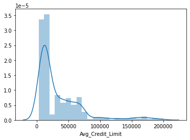

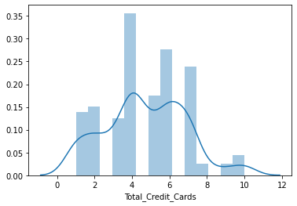

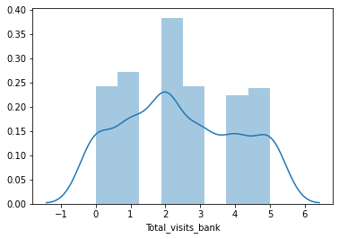

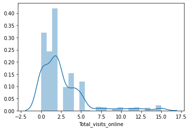

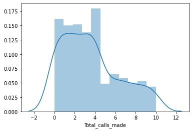

```python
for i in all_col:
    sns.distplot(data[i])
    plt.show()
```

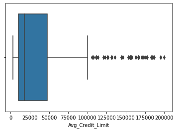

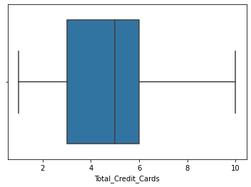

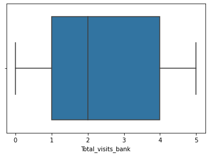

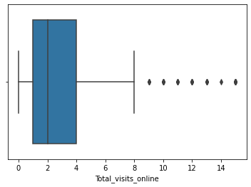

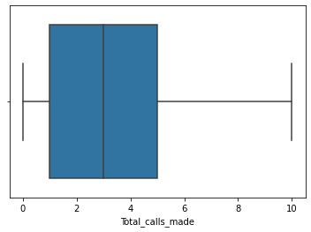

```python
for i in all_col:
    sns.boxplot(data[i])
    plt.show()
```

## Bivariabte EDA

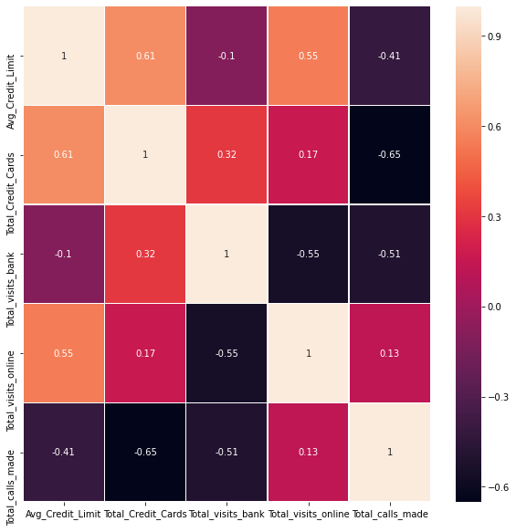

```python
plt.subplots(figsize=(10,10))
sns.heatmap(data.corr(), annot =True, linewidth=0.5)
```

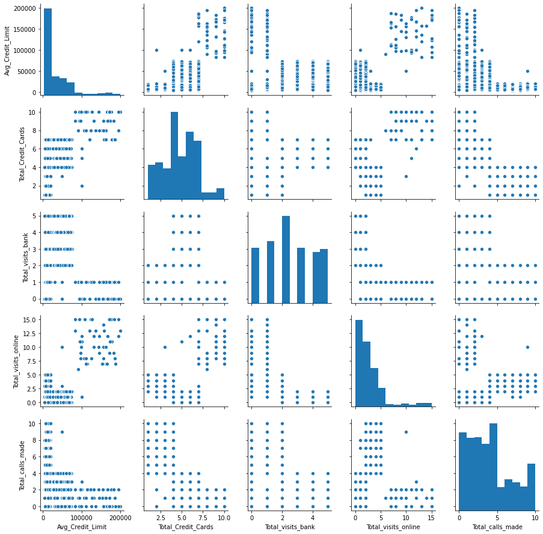

```python
sns.pairplot(data)
```

## Clustering

Scale the data before clustering to reduce unit problem

```python
scaler = StandardScaler()
copy_data = data[all_col].copy() # we need to use data again later, so don't change it
copy_data_scaled = scaler.fit_transform(copy_data)
scaled_data = pd.DataFrame(copy_data_scaled, columns=copy_data.columns)
scaled_data.head()
```

|  | Avg_Credit_Limit | Total_Credit_Cards | Total_visits_bank | Total_visits_online | Total_calls_made |
| --- | --- | --- | --- | --- | --- |
| 0 | 1.740187 | -1.249225 | -0.860451 | -0.547490 | -1.251537 |
| 1 | 0.410293 | -0.787585 | -1.473731 | 2.520519 | 1.891859 |
| 2 | 0.410293 | 1.058973 | -0.860451 | 0.134290 | 0.145528 |
| 3 | -0.121665 | 0.135694 | -0.860451 | -0.547490 | 0.145528 |
| 4 | 1.740187 | 0.597334 | -1.473731 | 3.202298 | -0.203739 |

## K-Mean Clustering

### Elbow Method

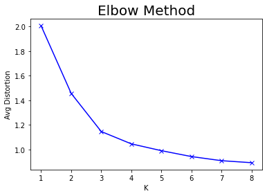

```python
elbow = range(1, 9)
avgDistortions = []

for k in elbow:
    model = KMeans(n_clusters=k)
    model.fit(scaled_data)
    prediction = model.predict(scaled_data)
    distortion = (
        sum(np.min(cdist(scaled_data, model.cluster_centers_, 'euclidean'), axis=1))
        /scaled_data.shape[0])
    avgDistortions.append(distortion)

plt.plot(elbow, avgDistortions, 'bx-')
plt.xlabel('K')
plt.ylabel('Avg Distortion')
plt.title('Elbow Method', fontsize=20)
```

### Silhouette Score

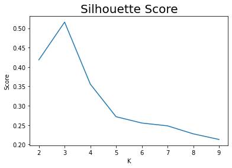

```python
cluster_list = range(2, 10)
sil_score = []
for n_clusters in cluster_list:
    clusterer = KMeans(n_clusters=n_clusters)
    preds = clusterer.fit_predict((scaled_data))
    score = silhouette_score(scaled_data, preds)
    sil_score.append(score)


plt.plot(cluster_list, sil_score)
plt.xlabel('K')
plt.ylabel('Score')
plt.title('Silhouette Score', fontsize=20)
```

Pretty Clear that 3 is good number for K.

```python
kmeans = KMeans(n_clusters=3, random_state=0)
kmeans.fit(scaled_data)
```

```
KMeans(n_clusters=3, random_state=0)
```

```python
#Add Which Clusters they belong
scaled_data['K_means_segments'] = kmeans.labels_
data['K_means_segments'] = kmeans.labels_
data.head()
```

|  | Avg_Credit_Limit | Total_Credit_Cards | Total_visits_bank | Total_visits_online | Total_calls_made | K_means_segments |
| --- | --- | --- | --- | --- | --- | --- |
| 0 | 100000 | 2 | 1 | 1 | 0 | 0 |
| 1 | 50000 | 3 | 0 | 10 | 9 | 1 |
| 2 | 50000 | 7 | 1 | 3 | 4 | 0 |
| 3 | 30000 | 5 | 1 | 1 | 4 | 0 |
| 4 | 100000 | 6 | 0 | 12 | 3 | 2 |

```python
cluster_profile = data.groupby('K_means_segments').mean()
cluster_profile['count_in_each_segment'] = (
    data.groupby('K_means_segments')['Total_Credit_Cards'].count().values
)
```

```python
# let's display cluster profiles
cluster_profile.style.highlight_max(color='lightgreen', axis=0)
```

| K_means_segments | Avg_Credit_Limit | Total_Credit_Cards | Total_visits_bank | Total_visits_online | Total_calls_made | count_in_each_segment |
| --- | --- | --- | --- | --- | --- | --- |
| 0 | 33782.4 | 5.51554 | 3.48964 | 0.981865 | 2 | 386 |
| 1 | 12174.1 | 2.41071 | 0.933036 | 3.55357 | 6.87054 | 224 |
| 2 | 141040 | 8.74 | 0.6 | 10.9 | 1.08 | 50 |

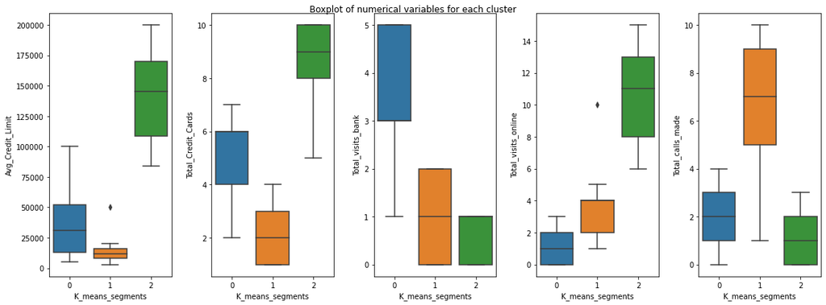

```python
fig, axes = plt.subplots(1, 5, figsize=(16, 6))
fig.suptitle('Boxplot of numerical variables for each cluster')
counter = 0
for i in range(5):
    sns.boxplot(ax=axes[i], y=data[all_col[counter]], x=data['K_means_segments'])
    counter = counter + 1

fig.tight_layout(pad=2.0)
```

```python
pd.crosstab(data.K_means_segments, data.Total_Credit_Cards).style.highlight_max(color="lightgreen", axis=0)
```

| Total_Credit_Cards K_means_segments | 1 | 2 | 3 | 4 | 5 | 6 | 7 | 8 | 9 | 10 |
| --- | --- | --- | --- | --- | --- | --- | --- | --- | --- | --- |
| 0 | 0 | 1 | 0 | 102 | 73 | 116 | 94 | 0 | 0 | 0 |
| 1 | 59 | 63 | 53 | 49 | 0 | 0 | 0 | 0 | 0 | 0 |
| 2 | 0 | 0 | 0 | 0 | 1 | 1 | 7 | 11 | 11 | 19 |

### Insights

These insights are written based on majorities.

- **Clusters 0**:
  - Credit Limit between: 15000-50000
  - Number of credit cards: 4-6
  - Total Number of bank visit: 3-5
  - Visiting online: 0-2
  - Calling bank: 1-3
- **Clusters 1**:
  - Credit Limit between: 0-15000
  - Number of credit cards: 0-3
  - Total Number of bank visit: 0-2
  - Visiting online: 2-4
  - Calling bank: 5-9
- **Clusters 2**:
  - Credit Limit between: 110000-170000
  - Number of credit cards: 8-10
  - Total Number of bank visit: 0-1
  - Visiting online: 8-13
  - Calling bank: 0-2

Seems pretty clear the customers have different ways of contacting/interacting with the bank.

## Hierarchical clustering

```python
# list of distance metrics
distance_metrics = ["euclidean", "chebyshev", "mahalanobis", "cityblock"]

# list of linkage methods
linkage_methods = ["single", "complete", "average", "weighted"]

high_dm_lm = [0, 0]

for dm in distance_metrics:
    for lm in linkage_methods:
        Z = linkage(scaled_data, metric=dm, method=lm)
        c, coph_dists = cophenet(Z, pdist(scaled_data))
        print(
            "Cophenetic correlation for {} distance and {} linkage is {}.".format(
                dm.capitalize(), lm, c
            )
        )
```

```
Cophenetic correlation for Euclidean distance and single linkage is 0.9125311786920032.
Cophenetic correlation for Euclidean distance and complete linkage is 0.9233120605315953.
Cophenetic correlation for Euclidean distance and average linkage is 0.9377289776168706.
Cophenetic correlation for Euclidean distance and weighted linkage is 0.918985765628112.
Cophenetic correlation for Chebyshev distance and single linkage is 0.8560343558461828.
Cophenetic correlation for Chebyshev distance and complete linkage is 0.8667150729267128.
Cophenetic correlation for Chebyshev distance and average linkage is 0.9301944455491864.
Cophenetic correlation for Chebyshev distance and weighted linkage is 0.9226851235364995.
Cophenetic correlation for Mahalanobis distance and single linkage is 0.9130983781874598.
Cophenetic correlation for Mahalanobis distance and complete linkage is 0.7355006687005069.
Cophenetic correlation for Mahalanobis distance and average linkage is 0.8175601213759511.
Cophenetic correlation for Mahalanobis distance and weighted linkage is 0.752008952000544.
Cophenetic correlation for Cityblock distance and single linkage is 0.9272888822057859.
Cophenetic correlation for Cityblock distance and complete linkage is 0.9190656310817734.
Cophenetic correlation for Cityblock distance and average linkage is 0.9345329585453204.
Cophenetic correlation for Cityblock distance and weighted linkage is 0.9122201247969678.
```

```python
# list of linkage methods only works with euclidean.
linkage_methods = ["centroid", "ward"]

high_dm_lm = [0, 0]

for lm in linkage_methods:
    Z = linkage(scaled_data, metric="euclidean", method=lm)
    c, coph_dists = cophenet(Z, pdist(scaled_data))
    print("Cophenetic correlation for {} linkage is {}.".format(lm, c))
```

```
Cophenetic correlation for centroid linkage is 0.933924274498229.
Cophenetic correlation for ward linkage is 0.8321686614948933.
```

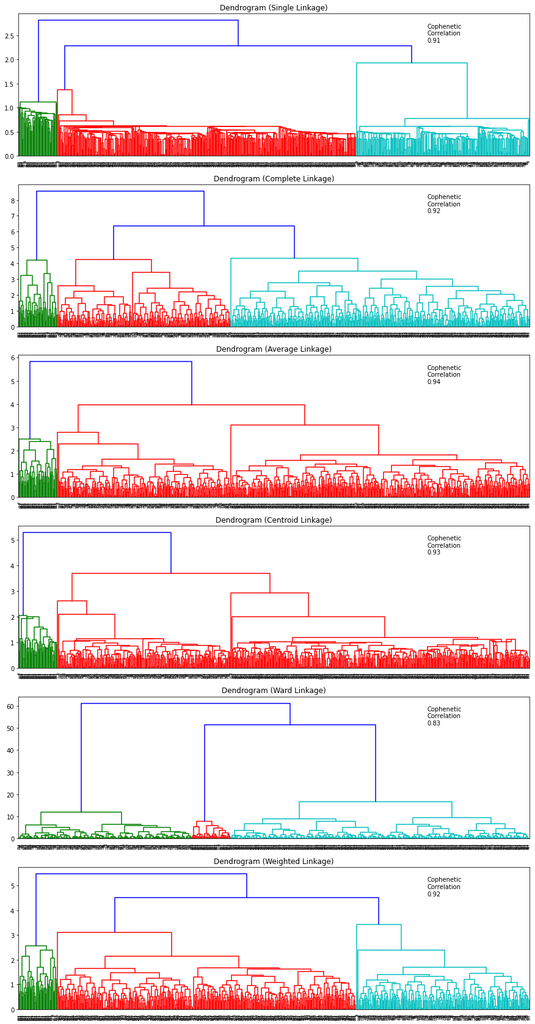

```python
# list of linkage methods
linkage_methods = ["single", "complete", "average", "centroid", "ward", "weighted"]

# lists to save results of cophenetic correlation calculation
compare_cols = ["Linkage", "Cophenetic Coefficient"]

# to create a subplot image
fig, axs = plt.subplots(len(linkage_methods), 1, figsize=(15, 30))

# We will enumerate through the list of linkage methods above
# For each linkage method, we will plot the dendrogram and calculate the cophenetic correlation
for i, method in enumerate(linkage_methods):
    Z = linkage(scaled_data, metric="euclidean", method=method)

    dendrogram(Z, ax=axs[i])
    axs[i].set_title(f"Dendrogram ({method.capitalize()} Linkage)")

    coph_corr, coph_dist = cophenet(Z, pdist(scaled_data))
    axs[i].annotate(
        f"Cophenetic\nCorrelation\n{coph_corr:0.2f}",
        (0.80, 0.80),
        xycoords="axes fraction",
    )
```

- Average Linkage has highest Cophenetic Correlation
- 3 seems to be good number of clusters

```python
HCmodel = AgglomerativeClustering(n_clusters=3, affinity="euclidean", linkage="average")
HCmodel.fit(scaled_data)
```

```
AgglomerativeClustering(linkage='average', n_clusters=3)
```

```python
#Add Which Clusters they belong
scaled_data["HC_Clusters"] = HCmodel.labels_
data["HC_Clusters"] = HCmodel.labels_
data.head()
```

|  | Avg_Credit_Limit | Total_Credit_Cards | Total_visits_bank | Total_visits_online | Total_calls_made | K_means_segments | HC_Clusters |
| --- | --- | --- | --- | --- | --- | --- | --- |
| 0 | 100000 | 2 | 1 | 1 | 0 | 0 | 0 |
| 1 | 50000 | 3 | 0 | 10 | 9 | 1 | 2 |
| 2 | 50000 | 7 | 1 | 3 | 4 | 0 | 0 |
| 3 | 30000 | 5 | 1 | 1 | 4 | 0 | 0 |
| 4 | 100000 | 6 | 0 | 12 | 3 | 2 | 1 |

```python
cluster_profile = data.groupby("HC_Clusters").mean()
cluster_profile["count_in_each_segments"] = (
    data.groupby("HC_Clusters")["Total_visits_bank"].count().values
)
```

```python
# let's display cluster profiles
cluster_profile.style.highlight_max(color="lightgreen", axis=0)
```

| HC_Clusters | Avg_Credit_Limit | Total_Credit_Cards | Total_visits_bank | Total_visits_online | Total_calls_made | K_means_segments | count_in_each_segments |
| --- | --- | --- | --- | --- | --- | --- | --- |
| 0 | 33782.4 | 5.51554 | 3.48964 | 0.981865 | 2 | 0 | 386 |
| 1 | 141040 | 8.74 | 0.6 | 10.9 | 1.08 | 2 | 50 |
| 2 | 12174.1 | 2.41071 | 0.933036 | 3.55357 | 6.87054 | 1 | 224 |

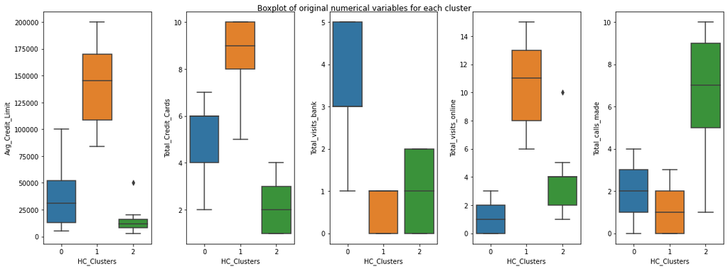

```python
fig, axes = plt.subplots(1, 5, figsize=(16, 6))
fig.suptitle("Boxplot of original numerical variables for each cluster")
counter = 0
for i in range(5):
    sns.boxplot(ax=axes[i], y=data[all_col[counter]], x=data["HC_Clusters"])
    counter = counter + 1

fig.tight_layout(pad=2.0)
```

### Insights

These insights are written based on majorities.

- **Clusters 0**:
  - Credit Limit between: 15000-50000
  - Number of credit cards: 4-6
  - Total Number of bank visit: 3-5
  - Visiting online: 0-2
  - Calling bank: 1-3
- **Clusters 1**:
  - Credit Limit between: 110000-170000
  - Number of credit cards: 8-10
  - Total Number of bank visit: 0-1
  - Visiting online: 8-13
  - Calling bank: 0-2
- **Clusters 2**:
  - Credit Limit between: 0-15000
  - Number of credit cards: 0-3
  - Total Number of bank visit: 0-2
  - Visiting online: 2-4
  - Calling bank: 5-9

Same as K-Mean Cluster except cluster 1&2 are switched.

## Compare Clusterings

```python
pd.crosstab(data.HC_Clusters, data.Total_Credit_Cards).style.highlight_max(color="lightgreen", axis=0)
```

| Total_Credit_Cards HC_Clusters | 1 | 2 | 3 | 4 | 5 | 6 | 7 | 8 | 9 | 10 |
| --- | --- | --- | --- | --- | --- | --- | --- | --- | --- | --- |
| 0 | 0 | 1 | 0 | 102 | 73 | 116 | 94 | 0 | 0 | 0 |
| 1 | 0 | 0 | 0 | 0 | 1 | 1 | 7 | 11 | 11 | 19 |
| 2 | 59 | 63 | 53 | 49 | 0 | 0 | 0 | 0 | 0 | 0 |

```python
pd.crosstab(data.K_means_segments, data.Total_Credit_Cards).style.highlight_max(color="lightgreen", axis=0)
```

| Total_Credit_Cards K_means_segments | 1 | 2 | 3 | 4 | 5 | 6 | 7 | 8 | 9 | 10 |
| --- | --- | --- | --- | --- | --- | --- | --- | --- | --- | --- |
| 0 | 0 | 1 | 0 | 102 | 73 | 116 | 94 | 0 | 0 | 0 |
| 1 | 59 | 63 | 53 | 49 | 0 | 0 | 0 | 0 | 0 | 0 |
| 2 | 0 | 0 | 0 | 0 | 1 | 1 | 7 | 11 | 11 | 19 |

## Concluson:

- It is more preferred to have more variables to use PCA and then initiate the clustering. More detailed information on customer could be helpful. The data is too correlated to each other.
- The customers have their own preferred methods of contacting the bank. They seems to have patterns according to the credit limit and number of credit cards owned.
- When advertising, it is important to target right group(cluster). Call service seems to have more numbers of contact. It is necessary to note, the more calls and visits occured could represent the customer service is not done correctly.
- However, it is also noticeable that customers with credit limit of 15000-50000 need less assistance from bank in general. Consider pushing out the similar information provided with groups of customers accordingly.